# PSTAT194 CS Section 4

Yue(Yuri) He

Spring 2022

```r
library(ggplot2)
library(dplyr)
library(tidyr)
```

# Monte Carlo

Monte Carlo methods, or Monte Carlo experiments, are a broad class of computational algorithms that rely on repeated random sampling to obtain numerical results. The underlying concept is to use randomness to solve problems that might be deterministic in principle.

Monte Carlo methods are mainly used in three problem classes:

- Optimization
- Numerical integration
- Generating draws from a probability distribution

Monte Carlo methods vary, but tend to follow a particular pattern:

1. Define a domain of possible inputs
2. Generate inputs randomly from a probability distribution over the domain
3. Perform a deterministic computation on the inputs
4. Aggregate the results

## Numerical integration

Many problems have “closed-form” solutions, meaning they can be solved with math alone. But there are also many problems for which no known closed-form solution exists. Integration is a classic example - there are many integrals for which a purely mathematical solution cannot be determined. However, solutions can be approximated using simulation.

Integration is ultimately about computing the area below the curve of a function.

### Estimate $\int_3^7x^2 dx$

Let’s look at a simple example where we have a “closed-form” solution to compare with. Suppose we want to find the integral from 3 to 7 of the following function:
$$f(x)=x^2$$

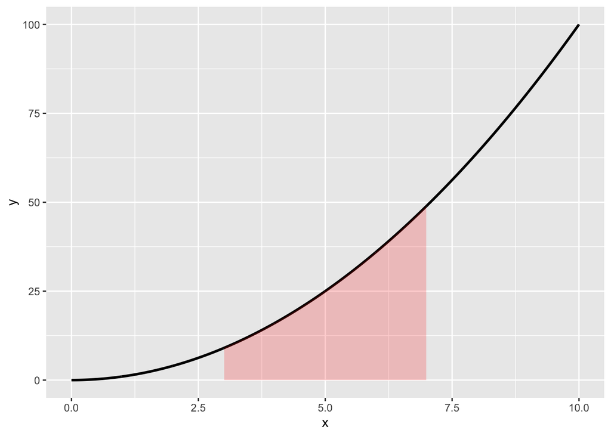

```r
desired_fun <- function(x){
  x^2
}
x <- seq(0,10,by=0.01)
y <- desired_fun(x)
df <- data.frame(x,y)
ggplot(df, aes(x,y)) +
  # theme_minimal() +
  geom_line(size=1) +
  geom_ribbon( data=subset(df, x>3 & x<7), aes(ymin=0,ymax=y),fill='red', alpha=0.2)
```

Note: option `alpha`range from 0 to 1, lower values corresponding to more transparent colors.

**How to estimate this result using Monte Carlo method?**

This result can be estimated via estimating the shaded area. The logic is to draw a bunch of random points inside a rectangle in the x-y plane that contains the shaded area, and then count how many fall below the function line. As number of trials increase, the ratio of points below the curve to the total number of points will be converge to the ratio of the area under f(x) to the total area of the rectangle. That is,
$$\frac{\text{# points under the curve}}{\text{# total points} }\approx\frac{\text{area under the curve}}{\text{area of the rectangle}}$$

As a result,
$$\frac{\text{# points under the curve}}{\text{# total points} }*{\text{area of the rectangle} }\approx\text{area under the curve}$$

So we’re going to do the following steps:

1. Define a domain of possible inputs: $x \in [3, 7]$ and $y \in [0, f(7)]$
2. Draw random points inside the box $[3, 7]\times[0, 49]$
3. Determine how many points below the $f(x)$
4. Compute the ratio*(area of the rectangle)

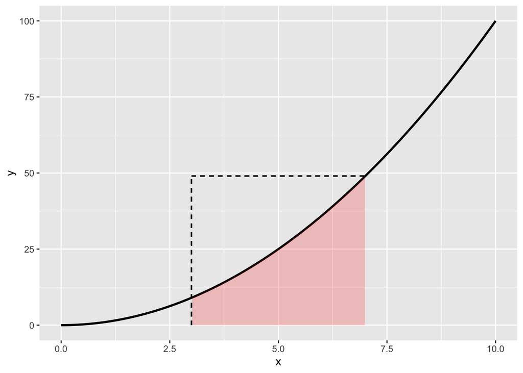

Generateing random points inside the box:

```r
numTrials <- 100000
# The function runif() samples from a "uniform" distribution
x <- runif(numTrials, min = 3, max = 7) # Values of x between 3 and 7
y <- runif(numTrials, min = 0, max = 7^2) # Values of y between 0 and 7^2
```

Estimating the area under the curve based on simulated observations:

```r
# Determine which y points are less than or equal to x^2:
belowCurve <- y <= x^2 # This will create a vector of TRUE and FALSE values
# Compute the ratio of points below the curve:
ratio <- sum(belowCurve) / numTrials
totalArea <- (7 - 3) * 7^2 # Rectangle length x height = 196
areaUnderCurve <- ratio * totalArea
areaUnderCurve
```

```
## [1] 105.5636
```

We know the correct solution is
$$\int_3^7x^2 dx=(\frac{x^3}{3})|^7_3=\frac{7^3}{3}-\frac{3^3}{3}\approx105.33$$

### Estimate $P(-2 \leq Z \leq 1)$

Now, let’s move on to a more completed example where we don’t have a “closed-form” solution. Suppose we want to calaulate the probability $P(-2 \leq Z \leq 1)$ where Z follows a standard normal distribution. Then, by definition
$$P(-2 \leq Z \leq 1)=\int_{-2}^{1}f(x)dx=\int_{-2}^{1}\frac{1}{\sqrt{2\pi}}e^{\frac{1}{2}x^2}dx$$
has no closed form solution. (f(x) stands for the pdf of standard normal r.v. Z.)

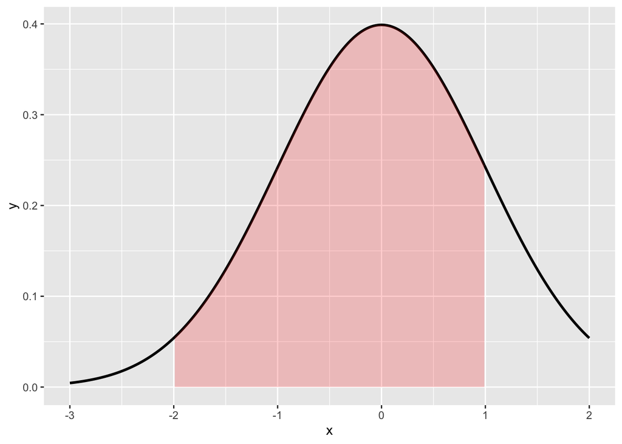

```r
x <- seq(-3,2,by=0.01)
y <- dnorm(x)
df <- data.frame(x,y)
ggplot(df, aes(x,y)) +
  # theme_minimal() +
  geom_line(size=1) +
  geom_ribbon( data=subset(df, x>-2 & x<1), aes(ymin=0,ymax=y),fill='red', alpha=0.2)
```

However, recall integration is about computing the area below the curve of a function. Then, similar to the previous example, we can estimate this probability through estimating the area under the curve. As number of trials increase, the ratio of points below the curve to the total number of points, times area of the rectangle will be converge to the area under pdf of standard normal. That is,

$$\frac{\text{# points under the curve}}{\text{# total points} }*{\text{area of the rectangle} }\approx\text{area under the curve}$$

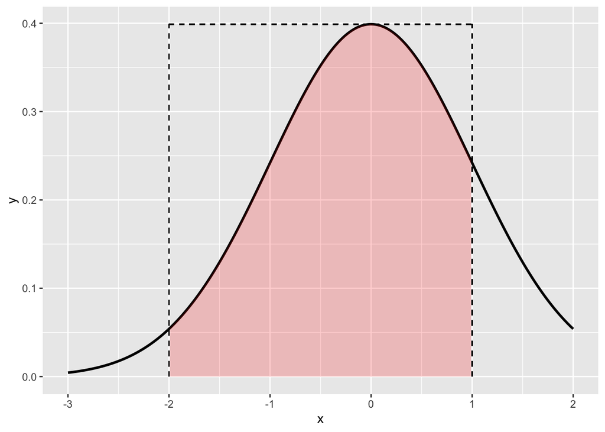

So we’re going to do the following steps:

1. Define a domain of possible inputs: $x \in [-2, 1]$ and $y \in [0, f(0)]$
2. Draw random points inside the box $[-2, 1]\times[0, f(0)]$
3. Determine how many points below the $f(x)$
4. Compute the ratio*(area of the rectangle)

Generateing random points inside the box:

```r
numTrials <- 100000
x <- runif(numTrials, min = -2, max = 1) # Values of x between -2 and 1
y <- runif(numTrials, min = 0, max = dnorm(0)) # Values of y between 0 and f(0)
```

Estimating the area under the curve based on simulated observations:

```r
# Determine which y points are under the standard normal pdf curve:
belowCurve <- y <= dnorm(x) # This will create a vector of TRUE and FALSE values
# Compute the ratio of points below the curve:
ratio <- sum(belowCurve) / numTrials
totalArea <- (1 - (-2)) * dnorm(0) # Rectangle length x height = 196
areaUnderCurve <- ratio * totalArea
areaUnderCurve
```

```
## [1] 0.8184859
```

Compare this with Z-table and build-in distribution function in R:
$$P(-2\leq Z \leq 1)=P(Z\leq1)-P(Z\leq-2)=P(Z\leq1)-(1-P(Z\leq2))=\Phi(1)+\Phi(2)-1=0.8413+0.9772-1=0.8185$$

```r
pnorm(1)-pnorm(-2)
```

```
## [1] 0.8185946
```

### Estimate $\pi$

Another example is approximating $\pi$.

The idea is to draw a bunch of random points inside a square that contains a circle with radius equals half of the side length of the square, and then count how many fall inside the circle. As number of trials increase, the ratio of points inside the circle to the total number of points will be converge to the ratio of the area of the circle to the area of the square.

The area of the circle is
$$A_{circle}=\pi r^2$$
The area of the square that containing that circle is
$$A_{circle}=4 r^2$$
Then the ratio of these two is
$$R = \frac{\pi r^2}{4r^2}=\frac{\pi}{4}$$
As a result,
$$4R = \pi$$

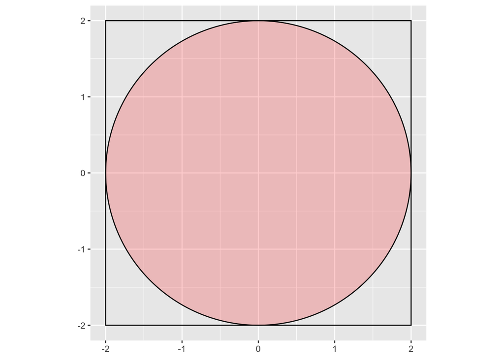

```r
library(ggforce)
ggplot()+
  geom_circle(aes(x0 = 0, y0 = 0, r = 2), fill='red', alpha=0.2)+
  coord_fixed()+
  geom_rect(aes(xmin=-2,xmax=2,ymin=-2,ymax=2),color='black',alpha=0)
```

So we’re going to do the following steps:

1. Define a domain of possible inputs: $x \in [-2, 2]$ and $y \in [-2, 2]$
2. Draw random points inside the square $[-2, 2]\times[-2, 2]$
3. Determine how many points fall inside the circle
4. Compute the ratio

Simulate random points in the square:

```r
set.seed(1)
numTrials <- 1000
df <- data.frame(
    x = runif(numTrials, -2, 2), # Values of x between -2 and 2
    y = runif(numTrials, -2, 2)) # Values of x between -2 and 2
head(df)
```

```
##            x          y
## 1 -0.9379653  0.1232352
## 2 -0.5115044  0.7394436
## 3  0.2914135 -0.4668664
## 4  1.6328312  1.8199520
## 5 -1.1932723 -1.5265737
## 6  1.5935587 -1.8435998
```

Label points inside the circle:

```r
points <- df %>%
    mutate(radius = sqrt(x^2 + y^2), pointInCircle = ifelse(radius <= 2, TRUE, FALSE))
head(points)
```

```
##            x          y    radius pointInCircle
## 1 -0.9379653  0.1232352 0.9460264          TRUE
## 2 -0.5115044  0.7394436 0.8991182          TRUE
## 3  0.2914135 -0.4668664 0.5503509          TRUE
## 4  1.6328312  1.8199520 2.4450691         FALSE
## 5 -1.1932723 -1.5265737 1.9376083          TRUE
## 6  1.5935587 -1.8435998 2.4368606         FALSE
```

To make sure we correctly labeled the points, let’s plot them, coloring them based on the pointInCircle variable we just created:

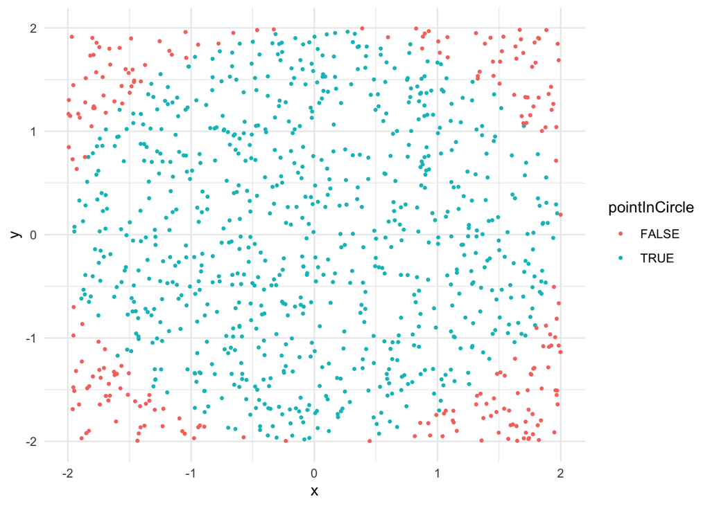

```r
ggplot(points) +
    geom_point(aes(x = x, y = y, color = pointInCircle), size = 0.7) +
    theme_minimal()
```

Looks right, let’s estimate $\pi$, recall
$$\pi=4R\approx4*\frac{\text{# points in the circle}}{\text{# total points}}$$

```r
ratio <- sum(points$pointInCircle) / nrow(points)
piApprox <- 4 * ratio
piApprox
```

```
## [1] 3.08
```

Estimate error is : 0.0615927

Let’s see what we get with 100,000 trials:

```r
numTrials <- 100000
points <- data.frame(
    x = runif(numTrials, -2, 2),
    y = runif(numTrials, -2, 2)) %>%
    mutate(
        radius = sqrt(x^2 + y^2),
        pointInCircle = ifelse(radius <= 2, TRUE, FALSE))
ratio <- sum(points$pointInCircle) / nrow(points)
piApprox <- 4 * ratio
piApprox
```

```
## [1] 3.13904
```

Estimate error is : 0.0025527

For many applications, Monte Carlo simulations result in a sufficiently accurate result with a reasonable amount of trials. You can always improve the accuracy with more trials, but that comes at the expense of increased run time.

## Generating draws from a probability distribution

We now turn to a discussion of how to generate sample values (i.e., random observations) from a specific distribution.

Suppose $X\sim f$, and we are interested in $E_f{h(X)}$ where
$$E_f{h(X)}=\int_{-\infty}^{\infty}h(x)f(x)dx\equiv\mu$$
If $X_1,...X_n \overset{\text{i.i.d}}{\sim}f$, then one can approximate $\mu$ by
$$\hat{\mu}_{MC}=\frac{1}{n}\sum_i^nh(x_i)$$
where MC $=$ Monte Carlo, since $\hat{\mu}_{MC}\underset{\text{a.s}}{\longrightarrow}\int_{-\infty}^{-\infty}h(x)f(x)dx=E_f{h(X)}$ as n$\rightarrow\infty$ if $E_f{|h(X_i)|}<\infty$ $\forall i$ by Strong Law of Large Numbers.

e.g. the general idea for estimating successful probability in Bernoulli trial is:

- Run a series of trials.
- Simulate an event (e.g. a coin toss, a dice roll, etc.) in each trial.
- Count the number of successful trials.
- Calulate observed odds = $\frac{\text{# successful trial} }{\text{# total trial}} \simeq$ expected odds for large trials.

### Inverse Transformation (Inverse CDF Sampling)

First, let’s consider the most fundamental technique for generating sample values of random variables–**Inverse Transformation**. It can be applied, at least in principle, in all cases where an explicit expression exists for the inverse cumulative distribution function of the random variable.

This method depends on the fact that, for any random variable X, the cdf F(x), is a nondecreasing function with $0 \leq F(x) \leq1$ for all values of x.

#### Cauchy Distribution

Let’s first see a continuous case, suppose we want to generate random samples from Cauchy distribution, and we know the CDF for Cauchy distribution is:
$$u=F(x)=\frac{1}{2}+\frac{1}{\pi}arctan(\frac{x-x_0}{\gamma})$$
where $x_0$ is the loaction paramter that controls where the peak is, and $\gamma$ is the scale parameter.

Since the inverse CDF is easy to solve and has a closed form, then we can directly use inverse transformation method to gnerate random samples:
$$x= F^{-1}(u)=\gamma tan(\pi(u-\frac{1}{2}))+x_0$$

We’re going to do the following steps:

1. Define domain of interest: [0,1]
2. Generate random numbers $u_i\in[0,1]$
3. Define the inverse of the desired CDF, e.g. $F^{-1}_X(u)$
4. Compute $x_i=F^{-1}_X(u_i)$

Generateing random numbers and define inverse Cauchy:

```r
numTrials <- 100000
u <- runif(numTrials) # Generate random number from U[0,1]

inverse_Cauchy<-function(u,x0,gamma){
  gamma*tan(pi*(u-1/2))+x0
}
```

Generate random samples from Cauchy distribution by plug in `inverse_Cauchy()`:

```r
x_sim <- sapply(u, inverse_Cauchy, x0 = 0, gamma = 1)
```

`sapply()`: apply a function over a list or vector.

Comparing with result generated by R build-in function `rcauchy()`:

```r
set.seed(2)
rcauchy_result <- rcauchy(numTrials, location = 0, scale = 1)

df <- data.frame(
    "Inverse_transform_generated" = x_sim,
    "Base_R_generated" = rcauchy_result)

head(df)
```

```
##   Inverse_transform_generated Base_R_generated
## 1                   2.2947681        0.6563479
## 2                   0.3796815       -1.3550135
## 3                   0.4348319       -4.2639434
## 4                   0.9291624        0.5831675
## 5                   0.3101516       -0.1782877
## 6                  12.8255734       -0.1794691
```

```r
df %>%
    pivot_longer(everything(), names_to = "method")
```

```
## # A tibble: 200,000 x 2
##    method                       value
##    <chr>                        <dbl>
##  1 Inverse_transform_generated  2.29
##  2 Base_R_generated             0.656
##  3 Inverse_transform_generated  0.380
##  4 Base_R_generated            -1.36
##  5 Inverse_transform_generated  0.435
##  6 Base_R_generated            -4.26
##  7 Inverse_transform_generated  0.929
##  8 Base_R_generated             0.583
##  9 Inverse_transform_generated  0.310
## 10 Base_R_generated            -0.178
## # … with 199,990 more rows
```

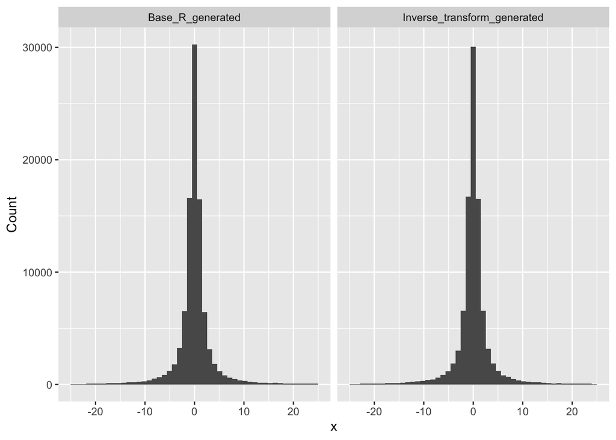

```r
df %>%
    pivot_longer(everything(), names_to = "method")%>%
    ggplot(aes(value)) +
        geom_histogram(bins = 50) +
        scale_x_continuous(limits = c(-25, 25)) +
        facet_wrap(~ method) +
        labs(x = "x", y = "Count")
```

where `scale_x_continuous()` and `scale_y_continuous()` are the default scales for continuous x and y aesthetics;

faceting is an alternative to using aesthetics (like colour, shape or size) to differentiate groups. Both techniques have strengths and weaknesses, based around the relative positions of the subsets. With faceting, each group is quite far apart in its own panel, and there is no overlap between the groups.

#### Laplace Distribution (HW2 Exercise 7)

The second continuous example is Laplace distribution (HW2 Exercise 7), suppose now we want to generate random samples from Laplace distribution, and we know the CDF for Laplace distribution is:
$$u=F(x)=\frac{1}{2}+\frac{1}{2}\text{sgn}(x)\left(1-e^{-|x|}\right), \quad x\in \mathcal R$$
(Note: $F(x) = \frac{1}{2}e^x=\int_{-\infty}^x\frac{1}{2}e^xdx$ for $x \leq0$; and $F(x) =1- \frac{1}{2}e^{-x}=\int_{-\infty}^0\frac{1}{2}e^xdx+\int_{0}^x\frac{1}{2}e^{-x}dx$ for $x >0$)

The inverse CDF is:
$$x= F^{-1}(u)=-\text{sgn}(u-\frac{1}{2})ln\left(1-2\left|u-\frac{1}{2}\right|\right), \quad u\in \mathcal [0,1]$$

We’re going to do the following steps:

1. Define domain of interest: [0,1]
2. Generate random numbers $u_i\in[0,1]$
3. Define the inverse of the desired CDF, e.g. $F^{-1}_X(u)$
4. Compute $x_i=F^{-1}_X(u_i)$

Generateing random numbers and define inverse Laplace:

```r
numTrials <- 100000
u <- runif(numTrials) # Generate random number from U[0,1]

inverse_Laplace<-function(u){
  -sign(u-1/2)*log(1-2*abs(u-1/2))
}
```

Generate random samples from Laplace distribution by plug in `inverse_Laplace()`:

```r
x_sim <- sapply(u, inverse_Laplace)
```

Comparing with result generated by function `rLaplace()` from package `ExtDist`:

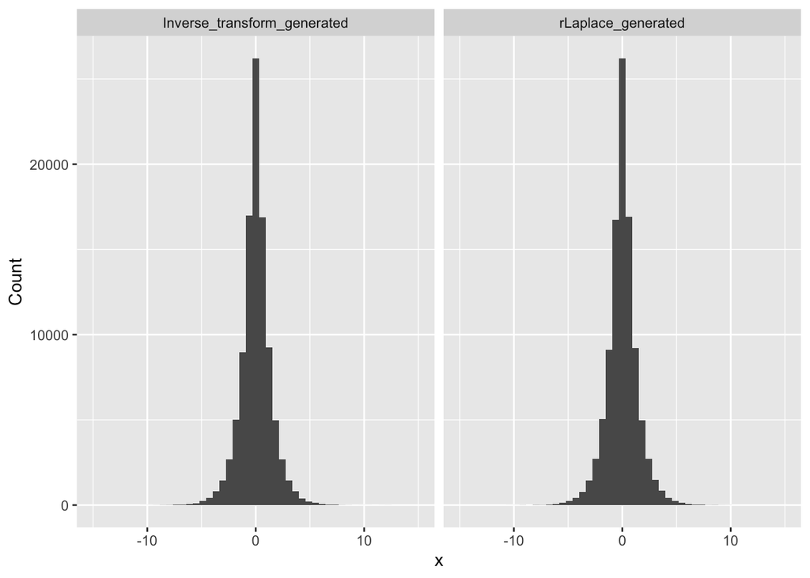

```r
library(ExtDist)
set.seed(2)
rLaplace_result <- rLaplace(numTrials, mu = 0, b = 1)

df <- data.frame(
    "Inverse_transform_generated" = x_sim,
    "rLaplace_generated" = rLaplace_result)

df %>%
    pivot_longer(everything(), names_to = "method")%>%
    ggplot(aes(value)) +
        geom_histogram(bins = 50) +
        scale_x_continuous(limits = c(-15, 15)) +
        facet_wrap(~ method) +
        labs(x = "x", y = "Count")
```

#### Discrete case

Suppose now we want to generate random samples from a discrete random variable X with probability mass function

| x | p(x) |
| --- | --- |
| 0 | 0.1 |
| 1 | 0.2 |
| 2 | 0.3 |
| 3 | 0.4 |

Then CDF $F(x)$ is:

| x | F(x) |
| --- | --- |
| <0 | 0 |
| 0 $\leq$ x <1 | 0.1 |
| 1 $\leq$ x<2 | 0.3 |
| 2 $\leq$ x<3 | 0.6 |
| $\geq$ 3 | 1 |

The inverse CDF $F^{-1}(u)$ is:

| u | $F^{-1}(u)$ |
| --- | --- |
| $\leq$ 0.1 | 0 |
| 0.1< u $\leq$ 0.3 | 1 |
| 0.3< u $\leq$ 0.6 | 2 |
| 0.6< u $\leq$ 1 | 3 |

**Method1**:

We’re going to do the following steps:

1. Define domain of interest: [0,1]
2. Generate random numbers $u_i\in[0,1]$
3. Define the inverse of the desired CDF, e.g. $F^{-1}_X(u)$
4. Compute $x_i=F^{-1}_X(u_i)$

Generateing random numbers and define inverse CDF:

```r
numTrials <- 100000
u <- runif(numTrials) # Generate random number from U[0,1]

inverse_cdf<-function(u){
  if(u<=0.1){
    return(0)
  }
  else if(0.1<u && u<=0.3){
    return(1)
  }
  else if(0.3<u && u<=0.6){
    return(2)
  }
  else{
    return(3)
  }
}
```

Generate random samples from this discrete distribution by plug in `inverse_cdf()`:

```r
x_sim <- sapply(u, inverse_cdf)
table1 <- table(x_sim)
table1
```

```
## x_sim
##     0     1     2     3
## 10028 19991 29829 40152
```

```r
table1/numTrials
```

```
## x_sim
##       0       1       2       3
## 0.10028 0.19991 0.29829 0.40152
```

**Method2**:

```r
x <- c(0,1,2,3)
p <- c(0.1,0.2,0.3,0.4)
cp <- cumsum(p)
cp
```

```
## [1] 0.1 0.3 0.6 1.0
```

```r
sample <- numeric(numTrials)

for(i in 1:numTrials){
  u <- runif(1)
  sample[i] <- x[min(which(u<=cp))]
}
est_p <- table(sample)/numTrials
round(rbind(p,est_p),4)
```

```
##         0      1      2      3
## p     0.1 0.2000 0.3000 0.4000
## est_p 0.1 0.1976 0.3017 0.4006
```

### Acceptance- Rejection Method

The idea of rejection sampling is that although we cannot easily sample from f, there exists another density g, like a Normal distribution or perhaps a t-distribution, from which it is easy for us to sample (because there’s a built in function or someone else wrote a nice function). Then we can sample from g directly and then “reject” the samples in a strategic way to make the resulting “non-rejected” samples look like they came from f.

Two things that need to be ensured:

1. Support of f is a subset of the support of g, b/c don’t want a region of the support of f that g can never touch, then that area will never get sampled.
2. $sup_x \frac{f(x)}{g(x)}<\infty$ (g has heavier tails than f)

Steps for A-R Method: (If target distribution is f and proposal distribution is g)

1. Draw a sample point $x$ from proposal distribution g (Using build-in functions, inverse CDF, etc)
2. Generate a random number $u \in[0,1]$
3. Decide whether accept $x$ from step 1 as a sample point from f by checking condition $u<\frac{f(x)}{Mg(x)}$; Yes—accept, No—reject
4. Repeat step 1-3 n times

#### Simulate Beta(3,4) (HW2 Exercise 4)

We’re going to do the following steps:

1. Draw a sample point $x$ from proposal distribution g
2. Generate a random number $u \in[0,1]$
3. Decide whether accept $x$ from step 1 as a sample point from f by checking condition $u<\frac{x^2(1-x)^3}{0.0264*(2-|4x-2|)}$; Yes—accept, No—reject
4. Repeat step 1-3 for $n=10000$ times

**Method1**:

```r
numTrials <- 10000
M <- 0.0264
f_sample <- c()
j<- 1
for(i in 1:numTrials){
  x<- mean(runif(2))
  u<- runif(1)
  x^2*(1-x)^3/(2-abs(4*x-2)) > M*u
  if (u< x^2*(1-x)^3/((2-abs(4*x-2))*M)) {
      f_sample[j] <- x
      j<- j+1
    }
}
```

Comparing with result generated by R build-in function `rbeta()`:

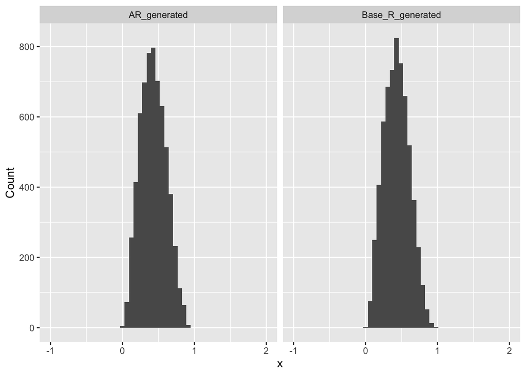

```r
set.seed(2)
rBeta_result <- rbeta(length(f_sample), 3,4)

df <- data.frame(
    "AR_generated" = f_sample,
    "Base_R_generated" = rBeta_result)

df %>%
    pivot_longer(everything(), names_to = "method")%>%
    ggplot(aes(value)) +
        geom_histogram(bins = 50) +
        scale_x_continuous(limits = c(-1, 2)) +
        facet_wrap(~ method) +
        labs(x = "x", y = "Count")
```

Comparing with true density curve generted by `dbeta()`:

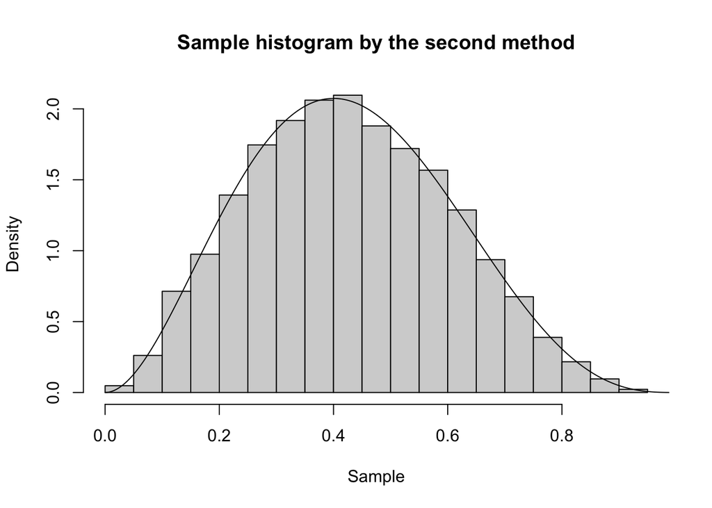

```r
hist(f_sample,probability = TRUE, xlab = "Sample", main="Sample histogram by the second method")
y <- seq(0,1,length.out = 1000)
lines(y, dbeta(y, 3, 4))
```

**Method2**:

```r
numTrials <- 10000
M <- 0.0264
x1<- runif(numTrials)
x2<- runif(numTrials)
x <- rowMeans(cbind(x1,x2))
for(i in 1:numTrials){
  x[i] = x[i]*(runif(1)< x[i]^2*(1-x[i])^3/((2-abs(4*x[i]-2))*M))
}
f_sample<- x[x!=0]
```

Comparing with true density curve generted by `dbeta()`:

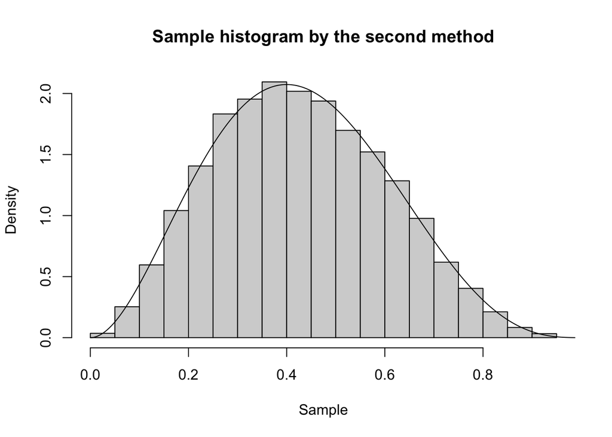

```r
hist(f_sample,probability = TRUE, xlab = "Sample", main="Sample histogram by the second method")
y <- seq(0,1,length.out = 1000)
lines(y, dbeta(y, 3, 4))
```

The second example is absolute standard normal distribution, suppose now our target distribution is $|Z|$ where $Z~\sim \mathcal{N}(0,1)$, with density:
$$f(x)=\frac{2}{\sqrt{2 \pi}}e^{-x^2/2}, \quad x\geq0$$
Proposal distribution is g exponential, with density
$$g(x)= e^{-x}, \quad x\geq0$$
Then M can be calculated via
$$M = sup_x\left(\frac{f(x)}{g(x)}\right)=sup_x\left(\frac{2}{\sqrt{2 \pi}}e^{x-x^2/2}\right)$$
How to solve this:

Method 1: set $h(x)=\frac{2}{\sqrt{2 \pi}}e^{x-x^2/2}$ and slove for $h'(x)=0$ Method 2: Use `optimize()` for $-log(h(x))=-log(2)+log(\sqrt{2\pi})-(x-\frac{x^2}{2})$

```r
neg_log_hx<- function(x){
 -log(2)+log(sqrt(2*pi))-(x-x^2/2)
}
supx <- optimize(neg_log_hx,lower=0,upper=10^5)
supx$minimum
```

```
## [1] 1
```

```r
M <- 2*exp(supx$minimum-supx$minimum^2/2)/sqrt(2*pi)
M
```

```
## [1] 1.315489
```

We’re going to do the following steps:

1. Draw a sample point $x$ from proposal distribution g using `rexp()`
2. Generate a random number $u \in[0,1]$
3. Decide whether accept $x$ from step 1 as a sample point from f by checking condition $u<\frac{\frac{2}{\sqrt{2 \pi}}e^{-x^2/2}}{1.32*e^{-x}}$; Yes—accept, No—reject
4. Repeat step 1-3 for $n=10000$ times

```r
numTrials <- 10000
M <- 1.32
x <- rexp(numTrials)
fx<-function(x){
  2*exp(-x^2/2)/sqrt(2*pi)
}
for(i in 1:numTrials){
  x[i] = x[i]*(runif(1)< fx(x[i])/(exp(-x[i])*M))
}
f_sample<- x[x!=0]
```

Comparing with true density curve generted by `f(x)`:

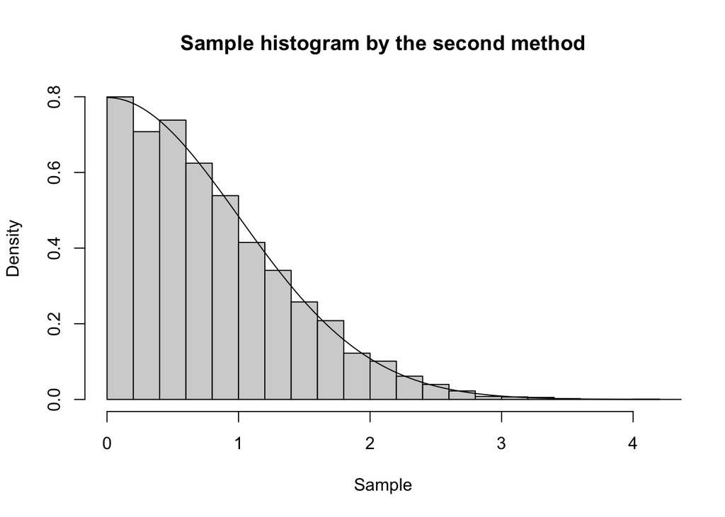

```r
hist(f_sample,breaks = 20, probability = TRUE, xlab = "Sample", main="Sample histogram by the second method")
y <- seq(0,6,length.out = 1000)
lines(y, fx(y))
```

#### Discrete case

Suppose now we want to generate random samples from a discrete random variable X with probability mass function

| x | f(x) |
| --- | --- |
| 1 | 0.1 |
| 2 | 0.2 |
| 3 | 0.3 |
| 4 | 0.4 |

If discrete unifrom distribution is used as proposal distribution with density:
$$g(x)=P(X=x)=\frac{1}{4}, \quad x\in\{1,2,3,4\}$$

Then, M can be computed as
$$M = sup_x\left(\frac{f(x)}{g(x)}\right)=4\times0.4=1.6$$
Meaning, the acceptance rate is $\frac{1}{1.6}=0.625$

We’re going to do the following steps:

1. Draw a sample point $x$ from proposal distribution g using `runif()`
2. Generate a random number $u \in[0,1]$
3. Decide whether accept $x$ from step 1 as a sample point from f by checking condition $u<\frac{f(x)}{1.6*g(x)}=\frac{f(x)}{0.4}$; Yes—accept, No—reject
4. Repeat step 1-3 for n times

Define number of trials, M and sample from proposal distribution g

```r
numTrials <- 100000
M <- 1.6
x<- floor(runif(numTrials,1,5))
table(x)
```

```
## x
##     1     2     3     4
## 24788 25023 24974 25215
```

Define $f(x)$ and accepct/reject samples from g

```r
value <- c(1,2,3,4)
p <- c(0.1,0.2,0.3,0.4)
fx<- function(x){
  return(p[which(value==x)])
}

for(i in 1:numTrials){
  x[i] = x[i]*(runif(1)< fx(x[i])/0.4)
}
f_sample<- x[x!=0]
table(f_sample)/length(f_sample)
```

```
## f_sample
##          1          2          3          4
## 0.09762339 0.20018872 0.29891565 0.40327224
```

### Importance Sampling

Recall, suppose $X\sim f$, and we are interested in $E_f{h(X)}$ where
$$E_f{h(X)}=\int_{-\infty}^{\infty}h(x)f(x)dx\equiv\mu$$
If $X_1,...X_n \overset{\text{i.i.d}}{\sim}f$, then one can approximate $\mu$ by
$$\hat{\mu}_{MC}=\frac{1}{n}\sum_{i=1}^nh(x_i)$$
where MC $=$ Monte Carlo, since $\hat{\mu}_{MC}\underset{\text{a.s}}{\longrightarrow}\int_{-\infty}^{-\infty}h(x)f(x)dx=E_f{h(X)}$ as n$\rightarrow\infty$ if $E_f{|h(X_i)|}<\infty$ $\forall i$ by Strong Law of Large Numbers.

The Monte Carlo sampling method is to simply sample x from the distribution f, apply function h on all samples, and take the average to get an estimation of the expectation. Then here comes the problem, what if f is very hard to sample from?

With rejection sampling, we ultimately obtain a sample from the target density f. However, with rejection sampling, if M is much larger than 1, then we will be generating a lot of candidates from g and ultimately throwing most of them away. What if we could take those rejected values and, instead of discarding them, simply downweight or upweight them in a specific way?

Rewrite target estimation $E_f{h(X)}=E_g\left[\frac{f(X)}{g(X)}h(X)\right]\equiv\mu$, then one can approximate $\mu$ by
$$\hat{\mu}=\frac{1}{n}\sum_{i=1}^n\frac{f(x_i)}{g(x_i)}h(x_i)$$
where $x_1,x_2,\dots,x_n\sim g$, and $\frac{f(x_i)}{g(x_i)}$ is called importance weights.

Steps for Importance sampling: (If target distribution is f and proposal distribution is g)

1. Draw n sample points $x$ from proposal distribution g (Using build-in functions, inverse CDF, etc)
2. Define $f(x)$ and $g(x)$
3. Apply function h on every sample points
4. Compute $\hat{\mu}=\frac{1}{n}\sum_{i=1}^n\frac{f(x_i)}{g(x_i)}h(x_i)$

#### Estimate $P(Z\geq 3)$

Suppose now we want to estimate $P(Z\geq 3)$ where $Z\sim \mathcal{N}(0,1)$ with pdf f:
$$P(Z\geq 3)=E_f[I_{\{Z\geq 3\}}]\equiv\mu$$
Then, by MC estimation:
$$\hat{\mu}_{MC}=\frac{1}{n}\sum_{i=1}^nI_{\{x_i\geq 3\}}=\frac{\text{# draws}\geq3}{n}$$

But note there won’t be many sample points greater than 3 (truth is 0.00135), result can be inaccurate:

```r
set.seed(4)
numTrials <- 10000
x<- rnorm(numTrials)
sum(x>3)/numTrials
```

```
## [1] 8e-04
```

Consider proposal distribution g: $X\sim \mathcal{N}(4,1)$

We’re going to do the following steps:

1. Draw n sample points $x$ from proposal distribution g using `rnorm()`
2. Define $f(x)$ and $g(x)$ (Use `dnorm()`)
3. Apply function h on every sample points, which is an indicator function in this case. Thus, assign 1 for every $x \geq 3$ and 0 otherwise.
4. Compute $\hat{\mu}=\frac{1}{n}\sum_{i, \forall x_i \geq3}\frac{f(x_i)}{g(x_i)}$

```r
set.seed(4)
numTrials <- 10000
x <- rnorm(numTrials,mean=4,sd=1)
for(i in 1:numTrials){
  x[i] = x[i]*(x[i]>=3)
}
x <- x[x!=0]
sum(dnorm(x)/dnorm(x,mean = 4, sd = 1))/numTrials
```

```
## [1] 0.001352687
```